# Проект Линейные модели в машинном обучении-git_1

```python
!pip install phik
```

```
     |████████████████████████████████| 686 kB 1.1 MB/s eta 0:00:01
```

```python
import pandas as pd
import numpy as np
from termcolor import colored # цвет
from matplotlib import pyplot as plt # графики
import seaborn as sns # графики
from scipy.stats import pearsonr
import phik # расчет коэффициентов корреляции
from sklearn.preprocessing import OneHotEncoder # метод преобразования качественных в количественные
from sklearn.preprocessing import StandardScaler # метод масштабирования
from sklearn.preprocessing import MinMaxScaler # метод для масштабирования
from sklearn.model_selection import train_test_split # разбика выборки на тренировочную и тестовую
from sklearn.linear_model import LinearRegression # линейная регрессия
from sklearn.linear_model import LogisticRegression # логистическая регрессия
from sklearn.metrics import mean_absolute_error # расчет ошибки
from sklearn.metrics import r2_score # расчет ошибки
from sklearn.metrics import mean_squared_error # импорт MSE для RMSE аргумент функции squared = False
from sklearn.cluster import KMeans # метод кластеризации
from sklearn.metrics import confusion_matrix # матрица ошибок (первый/второй год)
from sklearn.metrics import accuracy_score # проверка ошибки логистической регрессии
from sklearn.metrics import recall_score # ошибки второго рода
from sklearn.metrics import precision_score # Ошибки первого рода
```

## Загрузка данных

```python
ferma_main = pd.read_csv('/datasets/ferma_main.csv',sep=';')
ferma_dad = pd.read_csv('/datasets/ferma_dad.csv',sep=';')
cow_buy = pd.read_csv('/datasets/cow_buy.csv',sep=';')
```

```python
# Список атрибутов
def big_bold_text(text):
    return colored(text, attrs=['bold'])
```

## Предобработка данных

### 1. Проверка на наличие дубликатов, пропусков. Вывод формата данных в столбцах, структуры таблицы и наименование столбцов

```python
#Создадим словарь соответствия фрейма и его имени
dictionary_with_frames ={
    'ferma_main': ferma_main,
    'ferma_dad': ferma_dad,
    'cow_buy': cow_buy
}
#Функция тестировани данных
def test_df (dictionary_with_frames_col):
    for row in dictionary_with_frames_col:
        print(big_bold_text('Таблица: '),row)
        print(big_bold_text('Количество дубликатов: '),dictionary_with_frames[row].duplicated().sum())
        if dictionary_with_frames[row].duplicated().sum()>0:
            print('')
            print(big_bold_text('Строки с дубликатами:'))
            display(dictionary_with_frames[row].loc[dictionary_with_frames[row].duplicated()==True])
        print('')
        print(big_bold_text('Информация по таблице\n'))
        dictionary_with_frames[row].info()
        print('')
        print(big_bold_text('Количество пропусков:\n'))
        print(dictionary_with_frames[row].isna().sum())
        print('')
        print(big_bold_text('Вывод первых 5 строк из таблицы\n'))
        display(dictionary_with_frames[row].head(5))
        print(big_bold_text('_____________________________________________________________________________________________________'))
        print('')
test_df(dictionary_with_frames)
```

```
Таблица:  ferma_main
Количество дубликатов:  5

Строки с дубликатами:
```

|  | id | Удой, кг | ЭКЕ (Энергетическая кормовая единица) | Сырой протеин, г | СПО (Сахаро-протеиновое соотношение) | Порода | Тип пастбища | порода папы_быка | Жирность,% | Белок,% | Вкус молока | Возраст |
| --- | --- | --- | --- | --- | --- | --- | --- | --- | --- | --- | --- | --- |
| 629 | 627 | 5970 | 14,4 | 1837 | 0,88 | РефлешнСоверинг | Холмистое | Соверин | 3,64 | 3,075 | не вкусно | более_2_лет |
| 630 | 627 | 5970 | 14,4 | 1837 | 0,88 | РефлешнСоверинг | Холмистое | Соверин | 3,64 | 3,075 | не вкусно | более_2_лет |
| 631 | 627 | 5970 | 14,4 | 1837 | 0,88 | РефлешнСоверинг | Холмистое | Соверин | 3,64 | 3,075 | не вкусно | более_2_лет |
| 632 | 627 | 5970 | 14,4 | 1837 | 0,88 | РефлешнСоверинг | Холмистое | Соверин | 3,64 | 3,075 | не вкусно | более_2_лет |
| 633 | 627 | 5970 | 14,4 | 1837 | 0,88 | РефлешнСоверинг | Холмистое | Соверин | 3,64 | 3,075 | не вкусно | более_2_лет |

```
Информация по таблице

<class 'pandas.core.frame.DataFrame'>
RangeIndex: 634 entries, 0 to 633
Data columns (total 12 columns):
 #   Column                                 Non-Null Count  Dtype
---  ------                                 --------------  -----
 0   id                                     634 non-null    int64
 1   Удой, кг                               634 non-null    int64
 2   ЭКЕ (Энергетическая кормовая единица)  634 non-null    object
 3   Сырой протеин, г                       634 non-null    int64
 4   СПО (Сахаро-протеиновое соотношение)   634 non-null    object
 5   Порода                                 634 non-null    object
 6   Тип пастбища                           634 non-null    object
 7   порода папы_быка                       634 non-null    object
 8   Жирность,%                             634 non-null    object
 9   Белок,%                                634 non-null    object
 10  Вкус молока                            634 non-null    object
 11  Возраст                                634 non-null    object
dtypes: int64(3), object(9)
memory usage: 59.6+ KB

Количество пропусков:

id                                       0
Удой, кг                                 0
ЭКЕ (Энергетическая кормовая единица)    0
Сырой протеин, г                         0
СПО (Сахаро-протеиновое соотношение)     0
Порода                                   0
Тип пастбища                             0
порода папы_быка                         0
Жирность,%                               0
Белок,%                                  0
Вкус молока                              0
Возраст                                  0
dtype: int64

Вывод первых 5 строк из таблицы
```

|  | id | Удой, кг | ЭКЕ (Энергетическая кормовая единица) | Сырой протеин, г | СПО (Сахаро-протеиновое соотношение) | Порода | Тип пастбища | порода папы_быка | Жирность,% | Белок,% | Вкус молока | Возраст |
| --- | --- | --- | --- | --- | --- | --- | --- | --- | --- | --- | --- | --- |
| 0 | 1 | 5863 | 14,2 | 1743 | 0,89 | Вис Бик Айдиал | Равнинное | Айдиал | 3,58 | 3,076 | вкусно | более_2_лет |
| 1 | 2 | 5529 | 12,8 | 2138 | 0,89 | Вис Бик Айдиал | Равнинные | Соверин | 3,54 | 3,079 | вкусно | менее_2_лет |
| 2 | 3 | 5810 | 14 | 1854 | 0,885 | РефлешнСоверинг | Холмистое | Соверин | 3,59 | 3,074 | не вкусно | более_2_лет |
| 3 | 4 | 5895 | 12,4 | 2012 | 0,885 | РефлешнСоверинг | Холмистое | Айдиал | 3,4 | 3,075 | не вкусно | более_2_лет |
| 4 | 5 | 5302 | 12,8 | 1675 | 0,885 | Вис Бик Айдиал | Равнинные | Соверин | 3,73 | 3,073 | вкусно | менее_2_лет |

```
_____________________________________________________________________________________________________

Таблица:  ferma_dad
Количество дубликатов:  0

Информация по таблице

<class 'pandas.core.frame.DataFrame'>
RangeIndex: 629 entries, 0 to 628
Data columns (total 2 columns):
 #   Column    Non-Null Count  Dtype
---  ------    --------------  -----
 0   id        629 non-null    int64
 1   Имя Папы  629 non-null    object
dtypes: int64(1), object(1)
memory usage: 10.0+ KB

Количество пропусков:

id          0
Имя Папы    0
dtype: int64

Вывод первых 5 строк из таблицы
```

|  | id | Имя Папы |
| --- | --- | --- |
| 0 | 1 | Буйный |
| 1 | 2 | Соловчик |
| 2 | 3 | Барин |
| 3 | 4 | Буйный |
| 4 | 5 | Барин |

```
_____________________________________________________________________________________________________

Таблица:  cow_buy
Количество дубликатов:  4

Строки с дубликатами:
```

|  | Порода | Тип пастбища | порода папы_быка | Имя_папы | Текущая_жирность,% | Текущий_уровень_белок,% | Возраст |
| --- | --- | --- | --- | --- | --- | --- | --- |
| 6 | Вис Бик Айдиал | холмистое | Айдиал | Геркулес | 3,58 | 3,076 | более_2_лет |
| 8 | РефлешнСоверинг | равнинное | Соверин | Барин | 3,59 | 3,074 | более_2_лет |
| 14 | РефлешнСоверинг | равнинное | Соверин | Барин | 3,59 | 3,074 | более_2_лет |
| 19 | РефлешнСоверинг | равнинное | Айдиал | Буйный | 3,64 | 3,074 | более_2_лет |

```
Информация по таблице

<class 'pandas.core.frame.DataFrame'>
RangeIndex: 20 entries, 0 to 19
Data columns (total 7 columns):
 #   Column                   Non-Null Count  Dtype
---  ------                   --------------  -----
 0   Порода                   20 non-null     object
 1   Тип пастбища             20 non-null     object
 2   порода папы_быка         20 non-null     object
 3   Имя_папы                 20 non-null     object
 4   Текущая_жирность,%       20 non-null     object
 5   Текущий_уровень_белок,%  20 non-null     object
 6   Возраст                  20 non-null     object
dtypes: object(7)
memory usage: 1.2+ KB

Количество пропусков:

Порода                     0
Тип пастбища               0
порода папы_быка           0
Имя_папы                   0
Текущая_жирность,%         0
Текущий_уровень_белок,%    0
Возраст                    0
dtype: int64

Вывод первых 5 строк из таблицы
```

|  | Порода | Тип пастбища | порода папы_быка | Имя_папы | Текущая_жирность,% | Текущий_уровень_белок,% | Возраст |
| --- | --- | --- | --- | --- | --- | --- | --- |
| 0 | Вис Бик Айдиал | холмистое | Айдиал | Геркулес | 3,58 | 3,076 | более_2_лет |
| 1 | Вис Бик Айдиал | равнинное | Соверин | Буйный | 3,54 | 3,081 | менее_2_лет |
| 2 | РефлешнСоверинг | равнинное | Соверин | Барин | 3,59 | 3,074 | более_2_лет |
| 3 | РефлешнСоверинг | холмистое | Айдиал | Буйный | 3,4 | 3,061 | более_2_лет |
| 4 | РефлешнСоверинг | равнинное | Айдиал | Буйный | 3,64 | 3,074 | более_2_лет |

```
_____________________________________________________________________________________________________
```

**Вывод:**

**1.1 Удалим дубликаты**

```python
#удалим дубликаты
ferma_main = ferma_main.drop_duplicates().reset_index(drop=True)
```

**1.2 Сделаем преобразование типов данных**

```python
#Напишем функцию пробразования типов данных
#Создадим словарь соответствия полей и правильных типов данных
dictionary_with_frames ={
    'id': 'int64',
    'Удой, кг': 'int64',
    'ЭКЕ (Энергетическая кормовая единица)': 'float',
    'Сырой протеин, г' : 'int64',
    'СПО (Сахаро-протеиновое соотношение)' : 'float',
    'Порода' : 'object',
    'Тип пастбища' : 'object',
    'порода папы_быка' : 'object',
    'Жирность,%' : 'float',
    'Белок,%' : 'float',
    'Вкус молока' : 'object',
    'Возраст' : 'object'
}
```

```python
def type_data (dictionary_with_frames, df):
    for row in dictionary_with_frames:
        try:
            if dictionary_with_frames[row]=='object':
                df[row] = df[row].str.lower()
                df[row] = df[row].astype(dictionary_with_frames[row])
            else:
                df[row] = df[row].astype(dictionary_with_frames[row])
        except ValueError:
            for i in range(0, len(df[row])):
                # тут можно еще делать проверку типов, не совсем доработанная функци, но она работает)
                df.loc[i,row] = df.loc[i,row].replace(',','.')
            df[row] = df[row].astype(dictionary_with_frames[row])
    return df.info()
```

```python
type_data(dictionary_with_frames,ferma_main)
```

```
<class 'pandas.core.frame.DataFrame'>
RangeIndex: 629 entries, 0 to 628
Data columns (total 12 columns):
 #   Column                                 Non-Null Count  Dtype
---  ------                                 --------------  -----
 0   id                                     629 non-null    int64
 1   Удой, кг                               629 non-null    int64
 2   ЭКЕ (Энергетическая кормовая единица)  629 non-null    float64
 3   Сырой протеин, г                       629 non-null    int64
 4   СПО (Сахаро-протеиновое соотношение)   629 non-null    float64
 5   Порода                                 629 non-null    object
 6   Тип пастбища                           629 non-null    object
 7   порода папы_быка                       629 non-null    object
 8   Жирность,%                             629 non-null    float64
 9   Белок,%                                629 non-null    float64
 10  Вкус молока                            629 non-null    object
 11  Возраст                                629 non-null    object
dtypes: float64(4), int64(3), object(5)
memory usage: 59.1+ KB
```

```python
dictionary_with_frames ={
    'Порода': 'object',
    'Тип пастбища': 'object',
    'порода папы_быка': 'object',
    'Имя_папы': 'object',
    'Текущая_жирность,%': 'float',
    'Текущий_уровень_белок,%': 'float',
    'Возраст': 'object',
}
```

```python
type_data(dictionary_with_frames,cow_buy)
```

```
<class 'pandas.core.frame.DataFrame'>
RangeIndex: 20 entries, 0 to 19
Data columns (total 7 columns):
 #   Column                   Non-Null Count  Dtype
---  ------                   --------------  -----
 0   Порода                   20 non-null     object
 1   Тип пастбища             20 non-null     object
 2   порода папы_быка         20 non-null     object
 3   Имя_папы                 20 non-null     object
 4   Текущая_жирность,%       20 non-null     float64
 5   Текущий_уровень_белок,%  20 non-null     float64
 6   Возраст                  20 non-null     object
dtypes: float64(2), object(5)
memory usage: 1.2+ KB
```

```python
dictionary_with_frames ={
    'id': 'int64',
    'Имя Папы': 'object'
}
```

```python
type_data(dictionary_with_frames,ferma_dad)
```

```
<class 'pandas.core.frame.DataFrame'>
RangeIndex: 629 entries, 0 to 628
Data columns (total 2 columns):
 #   Column    Non-Null Count  Dtype
---  ------    --------------  -----
 0   id        629 non-null    int64
 1   Имя Папы  629 non-null    object
dtypes: int64(1), object(1)
memory usage: 10.0+ KB
```

Проверим категориальные значения на уникальность в df ferma_main, cow_buy

```python
col = ['Порода','Тип пастбища', 'порода папы_быка','Вкус молока', 'Возраст']
for row in col:
    print(ferma_main[row].unique())
```

```
['вис бик айдиал' 'рефлешнсоверинг']
['равнинное' 'равнинные' 'холмистое']
['айдиал' 'соверин' 'айдиалл']
['вкусно' 'не вкусно']
['более_2_лет' 'менее_2_лет']
```

```python
col = ['Порода', 'Тип пастбища', 'порода папы_быка', 'Имя_папы','Возраст']
for row in col:
    print(cow_buy[row].unique())
```

```
['вис бик айдиал' 'рефлешнсоверинг']
['холмистое' 'равнинное']
['айдиал' 'соверин']
['геркулес' 'буйный' 'барин' 'соловчик']
['более_2_лет' 'менее_2_лет']
```

Заменим в ferma_main значения на правильные

```python
ferma_main['Тип пастбища'] = ferma_main['Тип пастбища'].replace('равнинные','равнинное')
ferma_main['порода папы_быка'] = ferma_main['порода папы_быка'].replace('айдиалл','айдиал')
col = ['Порода','Тип пастбища', 'порода папы_быка','Вкус молока', 'Возраст']
for row in col:
    print(ferma_main[row].unique())
```

```
['вис бик айдиал' 'рефлешнсоверинг']
['равнинное' 'холмистое']
['айдиал' 'соверин']
['вкусно' 'не вкусно']
['более_2_лет' 'менее_2_лет']
```

Преобразуем наименование столбцов

```python
# Переименование колонок
new_column_names = {
    'id': 'id',
    'Удой, кг': 'удой_кг',
    'ЭКЕ (Энергетическая кормовая единица)': 'эке',
    'Сырой протеин, г' : 'сырой_протеин_г',
    'СПО (Сахаро-протеиновое соотношение)' : 'спо',
    'Порода' : 'порода',
    'Тип пастбища' : 'тип_пастбища',
    'порода папы_быка' : 'порода_папы_быка',
    'Жирность,%' : 'жирность_%',
    'Белок,%' : 'белок_%',
    'Вкус молока' : 'вкус_молока',
    'Возраст' : 'возраст'
}
# Применение новых имен колонок
ferma_main.rename(columns=new_column_names, inplace=True)
```

```python
new_column_names ={
    'Порода': 'порода',
    'Тип пастбища': 'тип_пастбища',
    'порода папы_быка': 'порода_папы_быка',
    'Имя_папы': 'имя_папы',
    'Текущая_жирность,%': 'жирность_%',
    'Текущий_уровень_белок,%': 'белок_%',
    'Возраст': 'возраст',
}
cow_buy.rename(columns=new_column_names, inplace=True)
```

```python
new_column_names ={
    'id': 'id',
    'Имя Папы': 'имя_папы'
}
ferma_dad.rename(columns=new_column_names, inplace=True)
```

### Вывод: удалены дубликаты, сделаны преобразования типов данных, заменены значения на правильные

## Исследовательский анализ данных

```python
ferma_main.describe()
```

|  | id | удой_кг | эке | сырой_протеин_г | спо | жирность_% | белок_% |
| --- | --- | --- | --- | --- | --- | --- | --- |
| count | 629.00000 | 629.000000 | 629.000000 | 629.000000 | 629.000000 | 629.000000 | 629.000000 |
| mean | 315.00000 | 6188.750397 | 14.543879 | 1923.364070 | 0.913116 | 3.603657 | 3.075671 |
| std | 181.72094 | 1644.795489 | 1.306408 | 182.956251 | 0.032203 | 0.168656 | 0.002549 |
| min | 1.00000 | 5204.000000 | 10.900000 | 1660.000000 | 0.840000 | 2.990000 | 3.069000 |
| 25% | 158.00000 | 5751.000000 | 13.500000 | 1771.000000 | 0.890000 | 3.590000 | 3.074000 |
| 50% | 315.00000 | 6133.000000 | 14.700000 | 1888.000000 | 0.930000 | 3.650000 | 3.076000 |
| 75% | 472.00000 | 6501.000000 | 15.600000 | 2062.000000 | 0.940000 | 3.720000 | 3.077000 |
| max | 629.00000 | 45616.000000 | 16.800000 | 2349.000000 | 0.960000 | 3.750000 | 3.085000 |

Наблюдается выброс в поле **Удой,кг**. Необходимо построить графики для визуального анализа данных

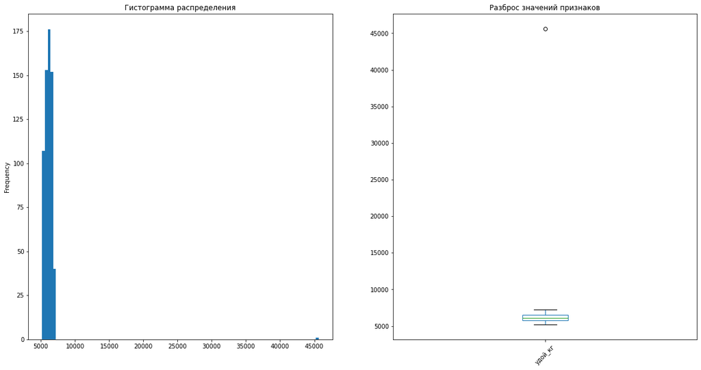

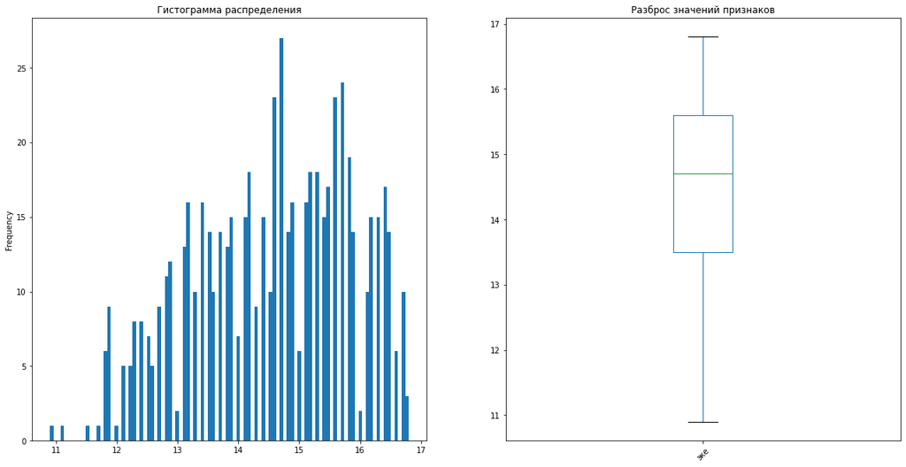

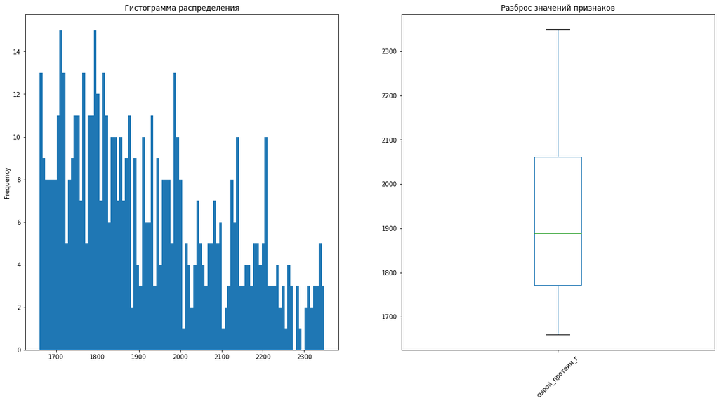

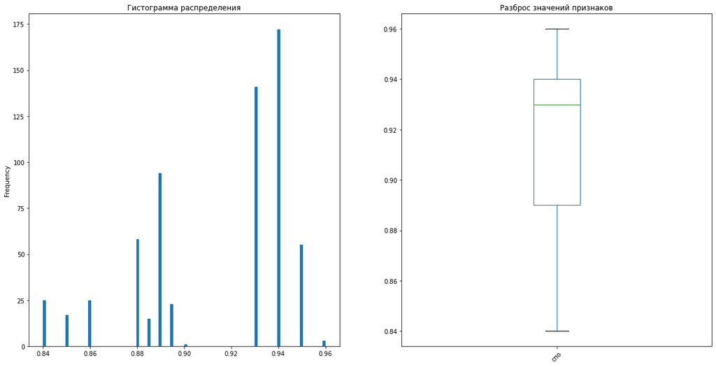

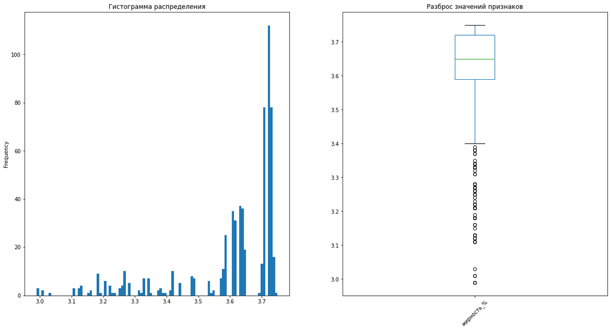

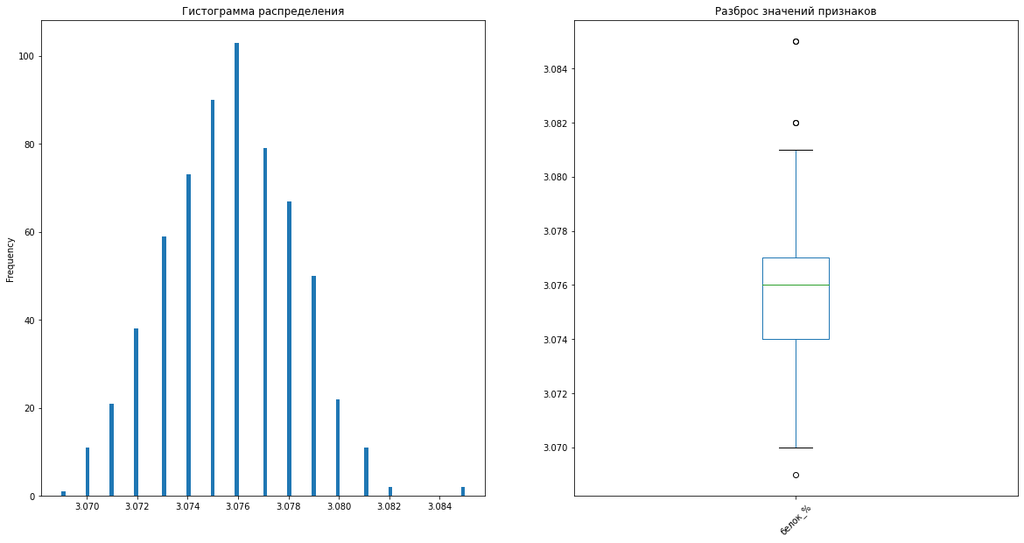

```python
#список количественных признаков исходной выборки
num_col_names = ['удой_кг',
                 'эке',
                 'сырой_протеин_г',
                 'спо',
                 'жирность_%',
                'белок_%']

# гистограмма частотности распределения и ящик с усами
for row in num_col_names:
    fig, axes = plt.subplots(nrows=1, ncols=2, figsize=(20,10))
    ferma_main[row].plot(kind='hist', bins=100, ax=axes[0])
    axes[0].set_title('Гистограмма распределения')
    ferma_main[row].plot(kind='box', ax=axes[1], rot=45)
    axes[1].set_title('Разброс значений признаков')
    plt.show()
```

Наблюдается выброс в поле **Удой,кг**. Будем удалять в данном поле выброс, так как это может сильно исказить модель при обучении.

```python
ferma_main=ferma_main.loc[ferma_main['удой_кг']!=max(ferma_main['удой_кг'])]
```

Повторим графичейский анализ полученной, после удаления выбросов

```python
ferma_main.describe()
```

|  | id | удой_кг | эке | сырой_протеин_г | спо | жирность_% | белок_% |
| --- | --- | --- | --- | --- | --- | --- | --- |
| count | 628.000000 | 628.000000 | 628.000000 | 628.000000 | 628.000000 | 628.000000 | 628.000000 |
| mean | 315.474522 | 6125.968153 | 14.548726 | 1923.759554 | 0.913089 | 3.604268 | 3.075670 |
| std | 181.475367 | 475.857053 | 1.301777 | 182.832816 | 0.032221 | 0.168093 | 0.002551 |
| min | 1.000000 | 5204.000000 | 10.900000 | 1660.000000 | 0.840000 | 2.990000 | 3.069000 |
| 25% | 158.750000 | 5749.750000 | 13.500000 | 1771.750000 | 0.890000 | 3.590000 | 3.074000 |
| 50% | 315.500000 | 6132.500000 | 14.700000 | 1888.000000 | 0.930000 | 3.650000 | 3.076000 |
| 75% | 472.250000 | 6501.000000 | 15.600000 | 2062.250000 | 0.940000 | 3.720000 | 3.077000 |
| max | 629.000000 | 7222.000000 | 16.800000 | 2349.000000 | 0.960000 | 3.750000 | 3.085000 |

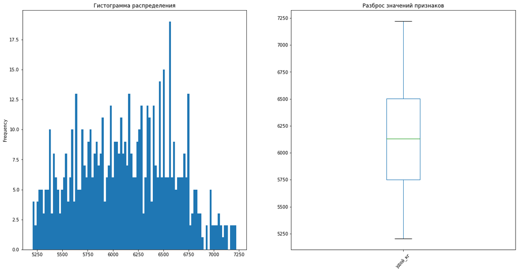

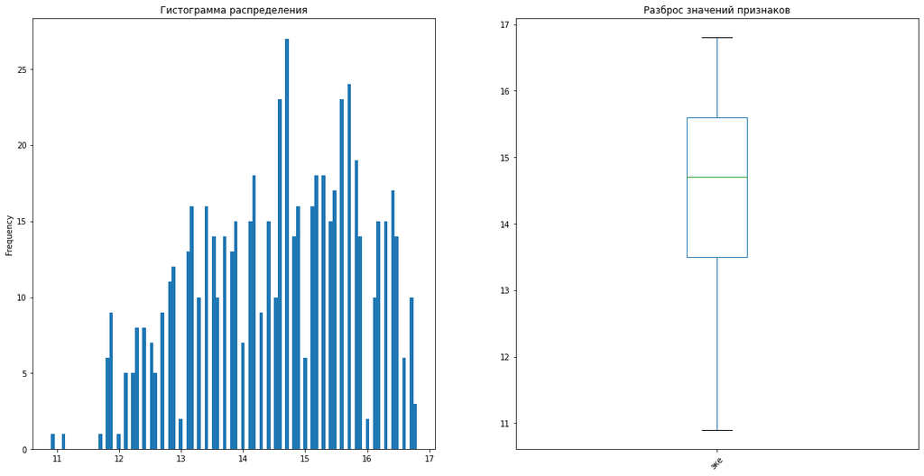

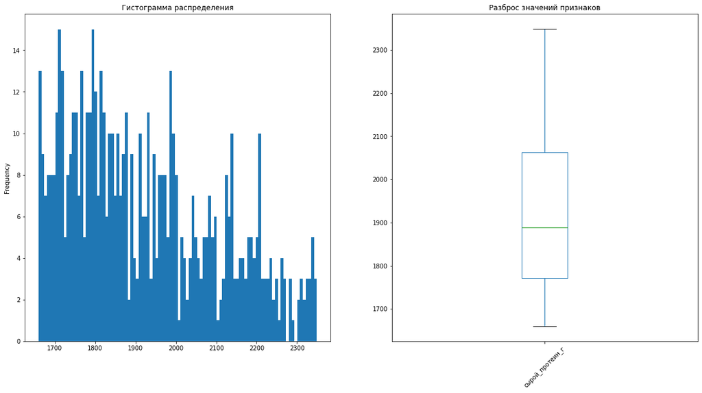

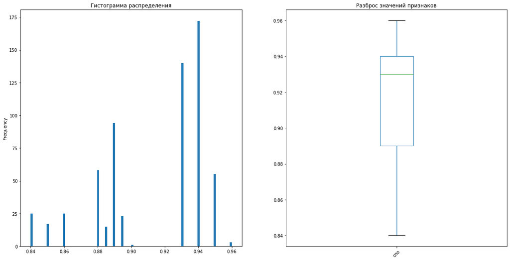

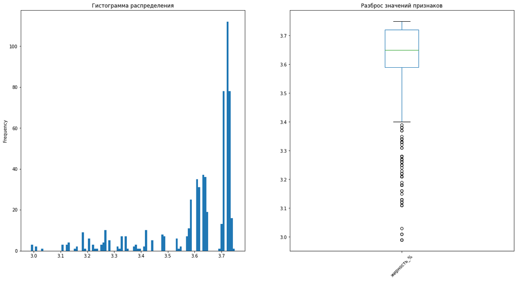

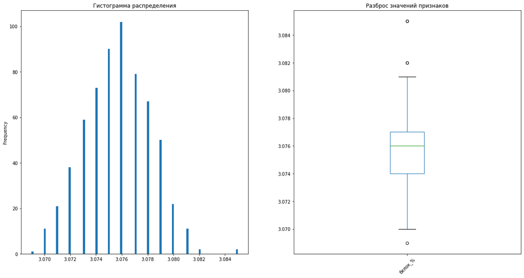

```python
#список количественных признаков тренировочной выборки
num_col_names = ['удой_кг',
                 'эке',
                 'сырой_протеин_г',
                 'спо',
                 'жирность_%',
                'белок_%']
# гистограмму частотности распределения и ящик с усами
for row in num_col_names:
    fig, axes = plt.subplots(nrows=1, ncols=2, figsize=(20,10))
    ferma_main[row].plot(kind='hist', bins=100, ax=axes[0])
    axes[0].set_title('Гистограмма распределения')
    ferma_main[row].plot(kind='box', ax=axes[1], rot=45)
    axes[1].set_title('Разброс значений признаков')
    plt.show()
```

**Предварительно проанализируем качественные показатели входных данных:**

1. Подтянем имя отца в исходную выборку (так как в тестовых данных у нас есть эта информация)
2. Посмотрим на распределение качественных данных
3. Посмотрим, есть ли в тренировочных данных коровы, чей удой и вкус молока нам необходимо предсказывать

```python
#Проанализируем качественные признаки входной выборки. Подтянем имя папы
ferma_main_full = pd.merge(ferma_main, ferma_dad, how = 'left')
```

```python
#Вывод данных без сворачивания to_string() to_html()
text_col = ['порода','тип_пастбища', 'порода_папы_быка','вкус_молока', 'возраст','имя_папы']
print(ferma_main_full[text_col].value_counts().to_string())
```

```
порода           тип_пастбища  порода_папы_быка  вкус_молока  возраст      имя_папы
вис бик айдиал   холмистое     айдиал            вкусно       более_2_лет  буйный      42
рефлешнсоверинг  холмистое     соверин           вкусно       более_2_лет  барин       40
                               айдиал            вкусно       более_2_лет  буйный      33
вис бик айдиал   холмистое     соверин           вкусно       более_2_лет  барин       33
                 равнинное     айдиал            вкусно       более_2_лет  буйный      31
                 холмистое     айдиал            не вкусно    более_2_лет  буйный      24
рефлешнсоверинг  холмистое     айдиал            не вкусно    более_2_лет  буйный      23
вис бик айдиал   равнинное     соверин           не вкусно    более_2_лет  барин       21
                               айдиал            не вкусно    более_2_лет  буйный      19
                                                 вкусно       более_2_лет  геркулес    18
                 холмистое     соверин           вкусно       более_2_лет  соловчик    18
рефлешнсоверинг  равнинное     айдиал            вкусно       более_2_лет  буйный      17
                               соверин           вкусно       более_2_лет  барин       16
                                                 не вкусно    более_2_лет  барин       15
вис бик айдиал   равнинное     соверин           вкусно       более_2_лет  соловчик    14
                               айдиал            не вкусно    более_2_лет  геркулес    13
рефлешнсоверинг  холмистое     соверин           не вкусно    более_2_лет  барин       13
вис бик айдиал   холмистое     соверин           вкусно       менее_2_лет  барин       13
рефлешнсоверинг  равнинное     айдиал            не вкусно    более_2_лет  буйный      12
вис бик айдиал   равнинное     соверин           не вкусно    более_2_лет  соловчик    11
                                                              менее_2_лет  соловчик    11
                                                 вкусно       более_2_лет  барин       11
                 холмистое     айдиал            не вкусно    более_2_лет  геркулес    11
                 равнинное     соверин           не вкусно    менее_2_лет  барин       10
рефлешнсоверинг  холмистое     айдиал            вкусно       более_2_лет  барин       10
                               соверин           не вкусно    менее_2_лет  барин       10
                                                 вкусно       более_2_лет  соловчик     9
вис бик айдиал   холмистое     соверин           не вкусно    более_2_лет  соловчик     9
рефлешнсоверинг  холмистое     соверин           вкусно       менее_2_лет  барин        9
вис бик айдиал   холмистое     айдиал            вкусно       более_2_лет  геркулес     9
                 равнинное     айдиал            не вкусно    менее_2_лет  буйный       9
рефлешнсоверинг  равнинное     соверин           не вкусно    менее_2_лет  барин        6
                                                              более_2_лет  соловчик     6
вис бик айдиал   холмистое     соверин           вкусно       менее_2_лет  соловчик     5
                               айдиал            вкусно       более_2_лет  барин        5
                               соверин           не вкусно    менее_2_лет  барин        5
                 равнинное     соверин           вкусно       менее_2_лет  соловчик     5
рефлешнсоверинг  равнинное     айдиал            вкусно       более_2_лет  геркулес     5
                 холмистое     соверин           не вкусно    более_2_лет  соловчик     5
```

[output cut: 16 more lines]

```
вис бик айдиал   равнинное     айдиал            вкусно       более_2_лет  барин        1
рефлешнсоверинг  холмистое     айдиал            вкусно       более_2_лет  геркулес     1
                 равнинное     соверин           не вкусно    менее_2_лет  соловчик     1
                                                 вкусно       менее_2_лет  соловчик     1
                               айдиал            не вкусно    менее_2_лет  геркулес     1
                                                                           барин        1
                                                              более_2_лет  соловчик     1
                                                                           геркулес     1
                                                                           барин        1
                                                 вкусно       менее_2_лет  буйный       1
вис бик айдиал   равнинное     айдиал            не вкусно    менее_2_лет  соловчик     1
                                                                           геркулес     1
                                                                           барин        1
                                                 вкусно       менее_2_лет  соловчик     1
рефлешнсоверинг  холмистое     соверин           не вкусно    менее_2_лет  соловчик     1
```

Можно заметить, что в выборке присутсвуют строки, которые повторяются менее 10 раз. Тут два варианта, либо по данной корове всегда было вкусно/не вкусно, либо было проведено мало экспериментов. Если записей мало, то велика доля вероятности, что модель в таких случаях будет ошибаться как по части предсказания удоя, так и по вкусовым качествам молока.

Посмотрим перекрестье между имеющимися данными у нас в выборке для обучения и на данные, которые нам необходимо предсказывать (тестовые данные).

```python
col_name_ferma = ['порода','тип_пастбища','порода_папы_быка','возраст','имя_папы']
col_name = ['порода','тип_пастбища','порода_папы_быка','возраст','имя_папы']
ferma_main_full_test=ferma_main_full[col_name_ferma].drop_duplicates().reset_index(drop=True)
# Объединение двух DataFrame с сохранением всех столбцов и добавлением столбца _merge
test_merg = pd.merge(cow_buy[col_name],ferma_main_full_test[col_name_ferma], how = 'left', \
                     left_on =col_name, right_on = col_name_ferma,indicator=True)
test_merg['_merge'].value_counts()
# for row in range(0,len(cow_buy)):
#     print(ferma_main_full_test.loc[(ferma_main_full_test[col_name_ferma[0]]==cow_buy.loc[row,col_name[0]])&\
#                                    (ferma_main_full_test[col_name_ferma[1]]==cow_buy.loc[row,col_name[1]])&\
#                                    (ferma_main_full_test[col_name_ferma[2]]==cow_buy.loc[row,col_name[2]])&\
#                                    (ferma_main_full_test[col_name_ferma[3]]==cow_buy.loc[row,col_name[3]])&\
#                                    (ferma_main_full_test[col_name_ferma[4]]==cow_buy.loc[row,col_name[4]])].to_string()
#                                    )
```

```
both          14
left_only      6
right_only     0
Name: _merge, dtype: int64
```

**Вывод**: Для покупки у нас есть такие варианты, которых нет в исторических данных. Таких вариантов 6  
То есть, мы не сможем точно предсказать их удой и вкус молока. Так же, в исторических данных есть коровы, у которых мало записей.  
Далее, необходимо произвести преобразование данных (каченственные в количественные) и построить матрицу корреляции

```python
test_merg.columns
```

```
Index(['порода', 'тип_пастбища', 'порода_папы_быка', 'возраст', 'имя_папы',
       '_merge'],
      dtype='object')
```

```
График:  порода
```

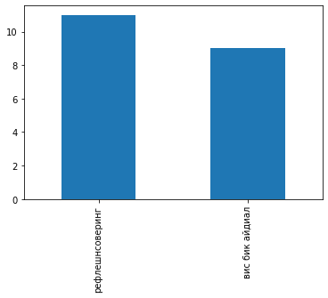

```
График:  тип_пастбища
```

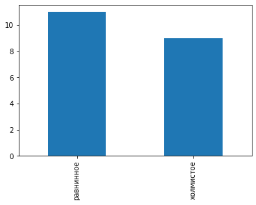

```
График:  порода_папы_быка
```

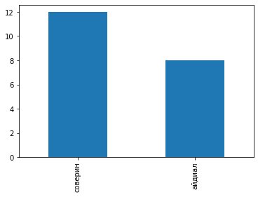

```
График:  возраст
```

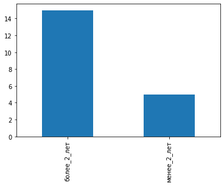

```
График:  имя_папы
```

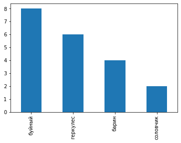

```python
col = ['порода', 'тип_пастбища', 'порода_папы_быка', 'возраст', 'имя_папы']
for row in col:
    print('График: ',row)
    test_merg[row].value_counts().plot(kind='bar')
    plt.show()
```

## Корреляционный анализ

Про мультиколлинеарность рассказывается в теме:*Логистическая регрессия: ограничения модели* (там добавляли новые признаки в модель) о мультиколлинеарности можно говорить, если кэф корредяции от 0.9-0.95

```python
colmn = ['удой_кг', 'эке','сырой_протеин_г', 'спо','жирность_%', 'белок_%']
ferma_main_full[colmn].corr()
```

|  | удой_кг | эке | сырой_протеин_г | спо | жирность_% | белок_% |
| --- | --- | --- | --- | --- | --- | --- |
| удой_кг | 1.000000 | 0.765098 | 0.446731 | 0.806339 | 0.600902 | 0.002966 |
| эке | 0.765098 | 1.000000 | 0.387875 | 0.749007 | 0.637279 | -0.008939 |
| сырой_протеин_г | 0.446731 | 0.387875 | 1.000000 | 0.446332 | 0.357793 | 0.226802 |
| спо | 0.806339 | 0.749007 | 0.446332 | 1.000000 | 0.629098 | 0.073718 |
| жирность_% | 0.600902 | 0.637279 | 0.357793 | 0.629098 | 1.000000 | -0.026542 |
| белок_% | 0.002966 | -0.008939 | 0.226802 | 0.073718 | -0.026542 | 1.000000 |

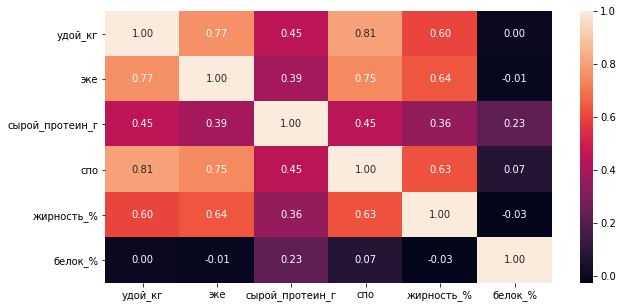

```python
fig, ax = plt.subplots(figsize=(10, 5))
sns.heatmap(ferma_main[colmn].corr(), annot=True, fmt='.2f')
```

```python
# Вычисление коэффициента корреляции Пирсона и p-значения
correlation, pvalue = pearsonr(ferma_main_full['удой_кг'],ferma_main_full['эке'])

# Вывод результатов
print("Коэффициент корреляции Пирсона:", correlation)
print("p-значение:", pvalue)
```

```
Коэффициент корреляции Пирсона: 0.7650977877344263
p-значение: 8.821932133848274e-122
```

**Вывод: Уже здесь мы можем наблюдать, что % содержания белка не имеет прямой зависимости между различными признаками. Однако, у остальных признаков присутствует линейная зависимость**.

Приведем качественные значения к числовому формату и попробуем найти линейную зависмость между признаками

Посмотрим на зависимость всех признаков при помощи универсального коэффициента Ф

```
interval columns not set, guessing: ['удой_кг', 'эке', 'сырой_протеин_г', 'спо', 'жирность_%', 'белок_%']
```

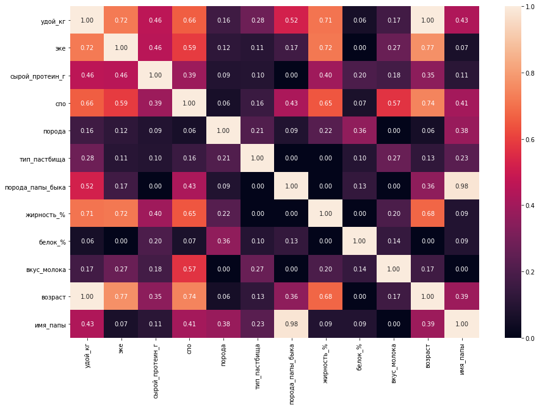

```python
fig, ax = plt.subplots(figsize=(15, 10))
sns.heatmap(ferma_main_full.drop('id', axis=1).phik_matrix(), annot=True, fmt='.2f')
```

```python
t_test = ferma_main_full.drop('id', axis=1)
```

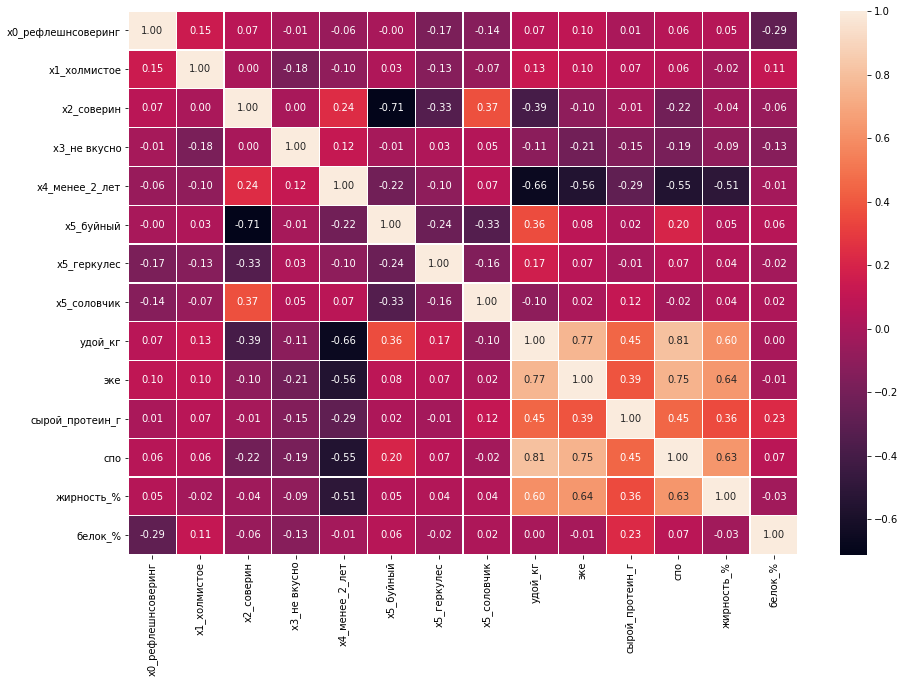

```python
# преобразуем качественные значения в количественные и нормализуем данные. Посмотрим на кор.анализ под таким углом
# Выделим количественные и качественные данные в выборке
col_1 = ['удой_кг', 'эке', 'сырой_протеин_г',
       'спо','жирность_%', 'белок_%']
kach_2 = ['порода', 'тип_пастбища','порода_папы_быка','вкус_молока', 'возраст','имя_папы']
# создадим переменную с экземпляром класса StandardScaler()
scaler = StandardScaler()

# обучим и трансформируем количественные признаки из тренировочной выборки
# сделаем это одной командой
X_train_scaled = scaler.fit_transform(t_test[col_1])


# создадим переменную с экземпляром класса OneHotEncoder()
# включим параметр для избегания появления дамми-ошибок,
# отключим sparse-отображение
encoder = OneHotEncoder(drop='first', sparse = False)

# обучим и трансформируем категориальные признаки из тренировочной выборки
# сделаем это одной командой
X_train_ohe = encoder.fit_transform(t_test[kach_2])

# получим от кодировщика список новых столбцов и сохраните в новой переменной
encoder_col_names = encoder.get_feature_names()

# создаём тренировочный и тестовый датафреймы из закодированных и отмасштабированных данных
# для данных OHE названия столбцов укажим из переменной encoder_col_names

X_train_ohe = pd.DataFrame(X_train_ohe, columns=encoder_col_names)

X_train_scaled = pd.DataFrame(X_train_scaled, columns=col_1)

# объединяем все преобразованные данные в тренировочный и тестовый датафреймы
# сбрасываем индексы в датафрейме с числовыми индексами, чтобы избежать ошибок

X_train = pd.concat([X_train_ohe, X_train_scaled], axis=1)

#sns.heatmap(X_train.corr(), annot=True, fmt='.2f')
fig, ax = plt.subplots(figsize=(15, 10))
sns.heatmap(X_train.corr(), annot=True, fmt='.2f',linewidths=.3)
#            cbar_kws={'shrink': .7}, figsize=(12, 8))
#print(X_train.head(5))
```

Построим диаграмму рассеивания целевого признака от входных параметров

```
Строим зависимость по удой, кг и  эке
Категориальный признак:  порода
Тип:  вис бик айдиал
Тип:  рефлешнсоверинг
```

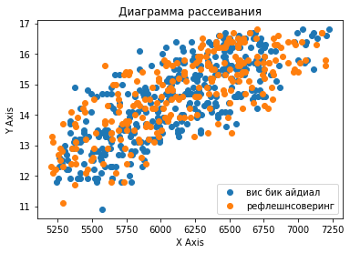

```
Категориальный признак:  тип_пастбища
Тип:  равнинное
Тип:  холмистое
```

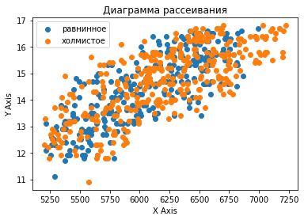

```
Категориальный признак:  порода_папы_быка
Тип:  айдиал
Тип:  соверин
```

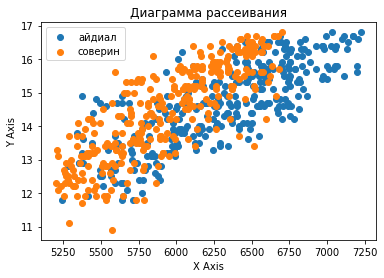

```
Категориальный признак:  возраст
Тип:  более_2_лет
Тип:  менее_2_лет
```

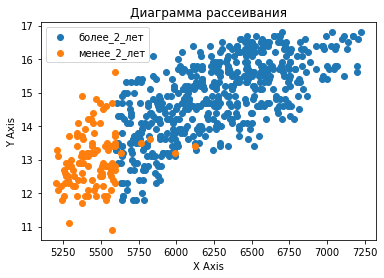

```
Строим зависимость по удой, кг и  сырой_протеин_г
Категориальный признак:  порода
Тип:  вис бик айдиал
Тип:  рефлешнсоверинг
```

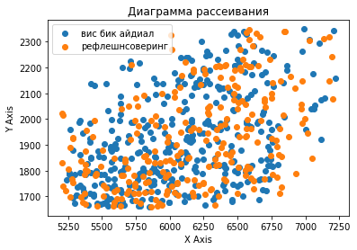

```
Категориальный признак:  тип_пастбища
Тип:  равнинное
Тип:  холмистое
```

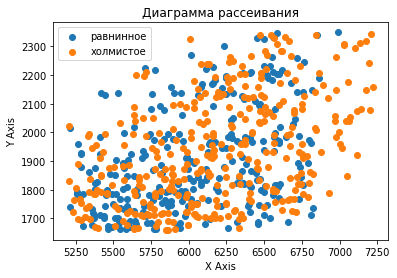

```
Категориальный признак:  порода_папы_быка
Тип:  айдиал
Тип:  соверин
```

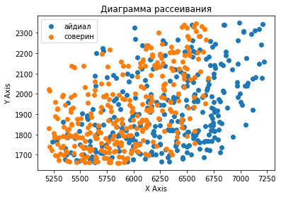

```
Категориальный признак:  возраст
Тип:  более_2_лет
Тип:  менее_2_лет
```

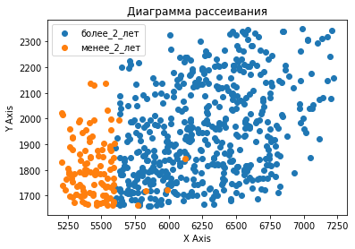

```
Строим зависимость по удой, кг и  спо
Категориальный признак:  порода
Тип:  вис бик айдиал
Тип:  рефлешнсоверинг
```

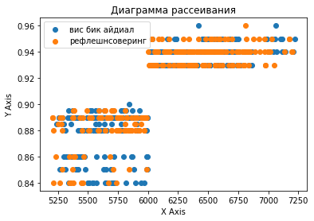

```
Категориальный признак:  тип_пастбища
Тип:  равнинное
Тип:  холмистое
```

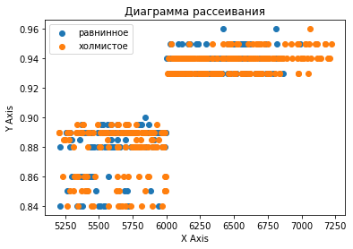

```
Категориальный признак:  порода_папы_быка
Тип:  айдиал
Тип:  соверин
```

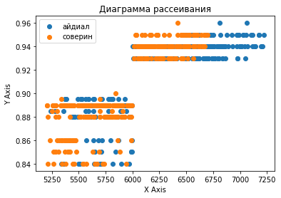

```
Категориальный признак:  возраст
Тип:  более_2_лет
Тип:  менее_2_лет
```

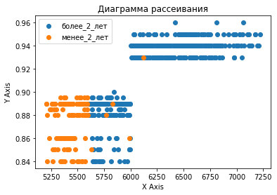

```
Строим зависимость по удой, кг и  жирность_%
Категориальный признак:  порода
Тип:  вис бик айдиал
Тип:  рефлешнсоверинг
```

[8 more figures not shown]

```python
cat_col_names = ['порода', 'тип_пастбища','порода_папы_быка','возраст']
num_col_names = ['эке', 'сырой_протеин_г',
                   'спо','жирность_%', 'белок_%']
# Заходим в количественные признаки
for row in num_col_names:
    print('Строим зависимость по удой, кг и ',row)
# Заходим в категориальные признаки
    for row_1 in cat_col_names:
        print('Категориальный признак: ',row_1)
# Берем категориальный признак и находим уникальное значение для него
        for row_2 in ferma_main_full[row_1].unique():
            print('Тип: ',row_2)
            x = ferma_main_full.loc[ferma_main_full[row_1]==row_2]['удой_кг']
            y = ferma_main_full.loc[ferma_main_full[row_1]==row_2][row]
            plt.scatter(x, y, label=row_2)
            # Добавление легенды
        plt.legend()

        # Настройка осей
        plt.xlabel('X Axis')
        plt.ylabel('Y Axis')

        # Название графика
        plt.title('Диаграмма рассеивания')

        # Показ графика
        plt.show()
        #for row in col:
```

**Вывод:** Между **'ЭКЕ (Энергетическая кормовая единица)'** и **'СПО (Сахаро-протеиновое соотношение)'** прослеживается практически одинаковая корреляция с целевым признаком. Посмотрим в дальнейшем, как это повлияет на модель.